# Atelier prédiction génomique : premiers pas

Lundi 17 février 2020

## Introduction

## R, rmarkdown, RStudio

- Cette présentation a été générée à partir d’un fichier texte au format Rmd utilisé par le logiciel libre [R](http://www.r-project.org/)
- La fonction `render` du package [rmarkdown](https://cran.r-project.org/web/packages/rmarkdown/index.html) permet de générer le fichier html à partir du fichier Rmd

```r
library(rmarkdown)
render("premiers-pas-slides.Rmd")
```

- Il est généralement plus simple pour faire ça d’utiliser le logiciel [RStudio](http://www.rstudio.com/)
- Le format Rmd permet également d’utiliser le language LaTeX pour écrire des équations

## Packages

- Cette présentation nécessite par ailleurs le chargement des packages [MASS](https://cran.r-project.org/web/packages/MASS/index.html) et [stats4](https://www.rdocumentation.org/packages/stats4/versions/3.6.2) qui sont généralement inclus par defaut dans R

```r
library(MASS)
library(stats4)
```

## Notation et vocabulaire

- L’inférence avec un modèle statistique consiste généralement à **estimer les paramètres**, puis à s’en servir pour **prédire de nouvelles données**
- Lorsqu’on propose un modèle, on commence par expliquer les **notations**
- **Conventions** :
  - lettres grecques pour les paramètres (non-observés), par exemple \(\theta\)
  - lettres romaines pour les données observées, \(y\)
  - lettres romaines surmontées d’un tilde pour les données prédites, \(\tilde{y}\)
  - les ensembles de données ou de paramètres sont généralement notés en majuscule, \(\mathcal{D} = \{ y_1, y_2, y_3 \}\) ou \(\Theta = \{ \theta_1, \theta_2 \}\)
  - s’il y a plusieurs paramètres ou données, ils se retrouvent mathématiquement dans des vecteurs, en gras, \(\boldsymbol{\theta}\) et \(\boldsymbol{y}\)
  - les vecteurs sont en colonne

## La notion de vraisemblance

- Une fois les notations établies, on écrit la **vraisemblance** (*likelihood*), souvent présentée comme étant la “probabilité des données sachant les paramètres”
- Si les données sont des **variables continues**, c’est la densité de probabilité des données sachant les paramètres, notée \(p(y | \theta)\), si les données sont des **variables discrètes**, c’est la fonction de masse, notée \(P(y | \theta)\)
- La vraisemblance est une fonction des **paramètres**, d’où le fait qu’on la note \(\mathcal{L}(\theta)\) ou \(\mathcal{L}(\theta | y)\)
- la méthode du **maximum de vraisemblance** cherche à identifier la valeur du paramètre, notée \(\hat{\theta}\) par convention, qui maximise la vraisemblance  
  \[ \begin{align} \hat{\theta} = \text{argmax}_\theta \, \mathcal{L} \; \; \Leftrightarrow \; \; \frac{\partial \mathcal{L}}{\partial \theta}(\hat{\theta}) = 0 \end{align} \]

## L’incertitude

- Certains décrivent les statistiques comme étant la “science de l’incertitude” ([Lindley, 2000](http://dx.doi.org/10.1111/1467-9884.00238))
- Pour l’instant, nous n’avons parlé que de la façon d’obtenir *une* valeur par paramètre, celle qui maximise la vraisemblance.
- Il est donc primordial ensuite de **quantifier l’incertitude** que nous avons quant à cette valeur
- C’est sur ce point que différentes approches sont possibles (**fréquentiste**, **bayésienne**).

## Comprendre la vraisemblance

- Supposons que l’on étudie une quantité physique dont la valeur résulte de la somme d’une très grande quantité de facteurs indépendants, chacun ayant un faible impact sur la valeur finale
- On prend trois mesures de cette quantité d’intérêt
- Comme il y a de la variation, on choisit d’introduire une **variable aléatoire** \(Y\) correspondant à la quantité d’intérêt, et on dénote par \(y_1\), \(y_2\) et \(y_3\) les trois observations, vues comme des réalisations de cette variable aléatoire :

\(y_1\) = 4.374, \(y_2\) = 5.184, \(y_3\) = 4.164

- Etant donné les caractéristiques du phénomène, il est raisonnable de supposer que la variable \(Y\) suit une **loi Normale** (c.f. le théorème central limite)
- Cette distribution de probabilité est caractérisée par deux paramètres, sa **moyenne** que l’on note généralement \(\mu\), et sa **variance** que l’on note généralement \(\sigma^2\) (\(\sigma\) étant l’écart-type)
- En terme de notation, on écrit \(Y \sim \mathcal{N}(\mu, \sigma^2)\), et la densité de probabilité de la réalisation \(y\) de \(Y\) s’écrit : \[ \begin{align} Y \sim \mathcal{N}(\mu, \sigma^2) \; \; \Leftrightarrow \; \; p(Y=y \, | \, \mu, \sigma) = \frac{1}{\sigma \sqrt{2 \pi}} \exp \left( - \frac{(y - \mu)^2}{2 \sigma^2} \right) \end{align} \]
- L’intérêt de ce modèle paramétrique est de pouvoir “résumer” les données, par exemple un million de mesures, par seulement deux valeurs, les paramètres
- Mais bien entendu, nous ne connaissons pas les valeurs de paramètres !
- La moyenne \(\mu\) peut prendre toutes les valeurs entre \(-\infty\) et \(+\infty\), et la variance \(\sigma^2\) n’a pour seule restriction que d’être positive
- La loi Normale peut être assez différente selon les valeurs de ces paramètres

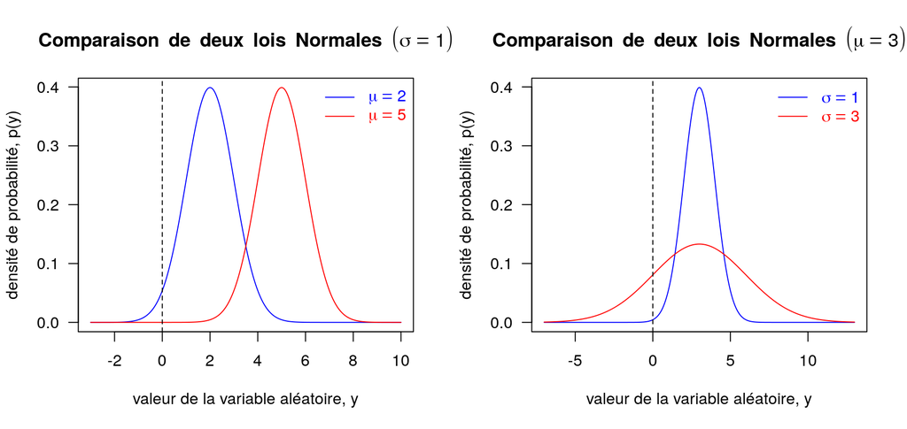

- Revenons à nos trois mesures : 4.374, 5.184, 4.164
- Parmi toutes les valeurs possibles des paramètres, quelles sont celles pour lesquelles la loi Normale est une bonne description du mécanisme qui a généré ces données ?
- Pour simplifier, supposons que l’on connaisse déjà la variance : \(\sigma^2 = 1\),  
  il ne nous reste plus qu’à trouver la moyenne : \(\mu\).
- Pour la première observation, \(y_1\) = 4.374 :

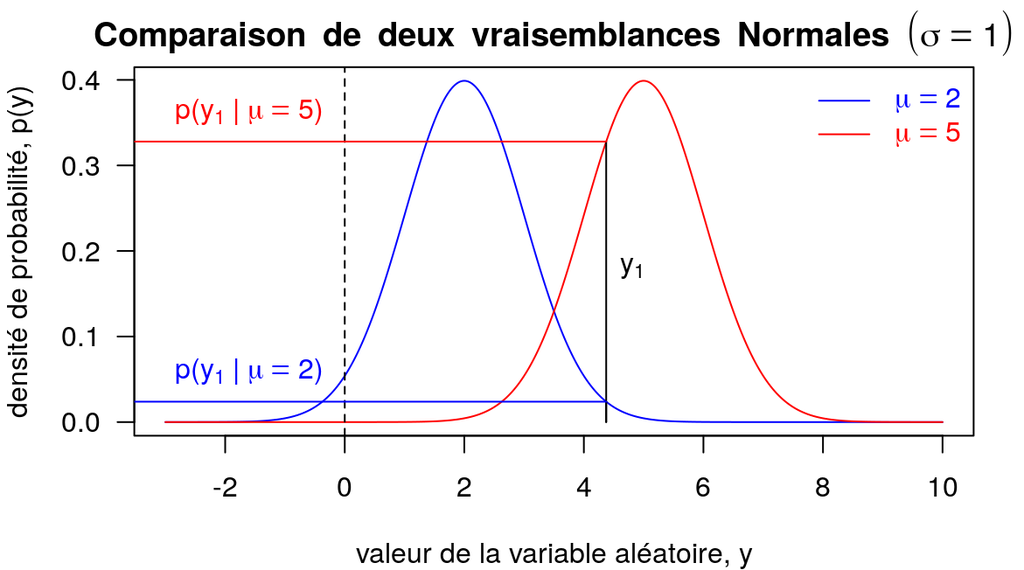

- D’après le graphique précédent : \(p(y_1 \, | \, \mu=5, \sigma=1) \, > \, p(y_1 \, | \, \mu=2, \sigma=1)\)
- Cela se vérifie si l’on fait le calcul avec la formule :
  - \(p(y_1 \, | \, \mu=5, \sigma=1)\) = 0.328
  - \(p(y_1 \, | \, \mu=2, \sigma=1)\) = 0.024
- Comme les deux densités ont la même valeur pour \(\sigma\), la différence vient bien du terme \((y - \mu)^2\) dans l’exponentielle, terme qui représente l’écart à la moyenne
- Au final, nous pouvons conclure pour la première observation, que la vraisemblance \(\mathcal{L}(\mu=5,\sigma=1)\) est plus grande que \(\mathcal{L}(\mu=2,\sigma=1)\)
- Comme on dispose de plusieurs observations, \(\{y_1,y_2,y_3\}\), et qu’on suppose qu’elles sont toutes des réalisations de la même variable aléatoire, \(Y\), il est pertinent de calculer la vraisemblance de toutes ces observations conjointement plutôt que séparément : \[ \begin{align} \mathcal{L}(\mu, \sigma) = p(y_1,y_2,y_3 \, | \, \mu, \sigma) \end{align} \]
- Si l’on fait aussi l’hypothèse que ces observations sont indépendantes, cela se simplifie en : \[ \begin{align} \mathcal{L}(\mu, \sigma) &= p(y_1 \, | \, \mu, \sigma) \times p(y_2 \, | \, \mu, \sigma) \times p(y_3 \, | \, \mu, \sigma) \\ &= \prod_{i=1}^3 p(y_i \, | \, \mu, \sigma) \end{align} \]
- Il n’est pas très pratique de maximiser la vraisemblance directement, on préfère passer au log (qui est monotone, donc le maximum de l’un est aussi le maximum de l’autre) : \[ \begin{align} l(\mu,\sigma) &= \log \mathcal{L}(\mu, \sigma) \\ &= \sum_{i=1}^3 \log p(y_i \, | \, \mu, \sigma) \\ &= \sum_{i=1}^3 \log \left[ \frac{1}{\sigma \sqrt{2 \pi}} \exp \left( - \frac{(y_i - \mu)^2}{2 \sigma^2} \right) \right] \\ &= - 3 \log \sigma \; - \frac{3}{2} \log (2\pi) \; - \frac{1}{2 \sigma^2} \sum_{i=1}^3 (y_i - \mu)^2 \end{align} \]
- En pratique, (i) on écrit une fonction qui calcule la log-vraisemblance, et (ii) on cherche le maximum de cette fonction

```r
compute.log.likelihood <- function(parameters, data){
  mu <- parameters[1]
  sigma <- parameters[2]
  y <- data
  n <- length(y)
  log.lik <- - n * log(sigma) - (n/2) * log(2 * pi) - sum(((y - mu)^2) / (2 * sigma^2))
  return(log.lik)
}

compute.log.likelihood(c(5,1), y)
```

```
## [1] -3.32
```

```r
compute.log.likelihood(c(2,1), y)
```

```
## [1] -13
```

- Dans le cas de la loi Normale, il existe déjà dans R des fonctions implémentant la densité de probabilité, ce qui nous permet de vérifier que nous n’avons pas fait d’erreur

```r
sum(dnorm(x=y, mean=5, sd=1, log=TRUE))
```

```
## [1] -3.32
```

```r
sum(dnorm(x=y, mean=2, sd=1, log=TRUE))
```

```
## [1] -13
```

## Ecrire le modèle

## Notations

- \(n\) : nombre d’individus (diploïdes, supposés non-apparentés)
- \(i\) : indice indiquant le \(i\)-ème individu, \(i \in \{1,\ldots,n\}\)
- \(y_i\) : phénotype de l’individu \(i\) pour la caractère d’intérêt
- \(\mu\) : moyenne globale du phénotype des \(n\) individus
- \(f\) : fréquence de l’allèle minoritaire au marqueur SNP d’intérêt
- \(x_i\) : génotype de l’individu \(i\) à ce SNP, codé comme le nombre de copie(s) de l’allèle minoritaire, \(\forall i \; x_i \in \{0,1,2\}\)
- \(\beta\) : effet additif de chaque copie de l’allèle minoritaire en unité du phénotype
- \(\epsilon_i\) : erreur pour l’individu \(i\)
- \(\sigma^2\) : variance des erreurs

## Notations (suite)

- Données : \(\mathcal{D} = \{ (y_1 \, | \, x_1), \ldots, (y_n \, | \, x_n) \}\)
- Paramètres : \(\Theta = \{ \mu, \beta, \sigma \}\)

## Vraisemblance

- On suppose que le génotype au SNP d’intérêt a un effet additif sur la moyenne du phénotype, ce qui s’écrit généralement : \[ \begin{align} \forall i \; \; y_i = \mu + \beta x_i + \epsilon_i \text{ avec } \epsilon_i \overset{\text{i.i.d}}{\sim} \mathcal{N}(0, \sigma^2) \end{align} \]
- Une autre façon équivalente de l’écrire : \[ \begin{align} \forall i \; \; y_i \, | \, x_i, \mu, \beta, \sigma \; \overset{\text{i.i.d}}{\sim} \mathcal{N}(\mu + \beta x_i, \sigma^2) \end{align} \]

## Simuler des données

- Initialisation :  
  On utilise un générateur de nombres pseudo-aléatoires qui peut être initialisé avec une graine (seed), ce qui est très utile pour la reproductibilité des analyses

```r
set.seed(1866) # année de parution de l'article de Mendel fondant la génétique
```

- Nombre d’individus :

```r
n <- 200
```

- Moyenne générale :

```r
mu <- 50
```

- Génotypes (on suppose que la population est à l’équilibre d’Hardy-Weinberg) :

```r
##' Genotype frequencies
##'
##' Calculate the genotype frequencies at a locus assuming the Hardy-Weinberg equilibrium
##' (https://en.wikipedia.org/wiki/Hardy%E2%80%93Weinberg_principle).
##' @param maf frequency of the minor allele, a
##' @return vector of genotype frequencies
##' @author Timothee Flutre
calcGenoFreq <- function(maf){
  stopifnot(is.numeric(maf), length(maf) == 1, maf >= 0, maf <= 0.5)
  geno.freq <- c((1 - maf)^2,
                2 * (1 - maf) * maf,
                maf^2)
  names(geno.freq) <- c("AA", "Aa", "aa")
  return(geno.freq)
}
f <- 0.3
genotypes <- sample(x=c(0,1,2), size=n, replace=TRUE, prob=calcGenoFreq(f))
```

```r
head(genotypes)
```

```
## [1] 2 0 1 0 1 1
```

```r
table(genotypes)
```

```
## genotypes
##   0   1   2
## 102  80  18
```

```r
sum(genotypes) / (2 * n) # estimate of the MAF
```

```
## [1] 0.29
```

```r
var(genotypes) # important for the estimate of beta
```

```
## [1] 0.426
```

- Effet du génotype sur le phénotype, \(\beta\) :

```r
(beta <- rnorm(n=1, mean=2, sd=1))
```

```
## [1] 2.45
```

- Erreurs, \(\boldsymbol{\epsilon}\) (par simplicité, on fixe \(\sigma\) à 1) :

```r
sigma <- 1
errors <- rnorm(n=n, mean=0, sd=sigma)
```

- Nous avons maintenant tout ce qu’il faut pour simuler les phénotypes, \(\boldsymbol{y}\), via l’équation précédente : \(y_i = \mu + \beta x_i + \epsilon_i\)

```r
phenotypes <- mu + beta * genotypes + errors
```

- Il est habituel dans R d’organiser les données dans un tableau

```r
dat <- data.frame(x=genotypes, y=phenotypes)
head(dat)
```

```
##   x    y
## 1 2 52.7
## 2 0 50.2
## 3 1 53.6
## 4 0 49.1
## 5 1 51.7
## 6 1 52.9
```

## Réaliser l’inférence

## Visualisation graphique

- Distribution du phénotype

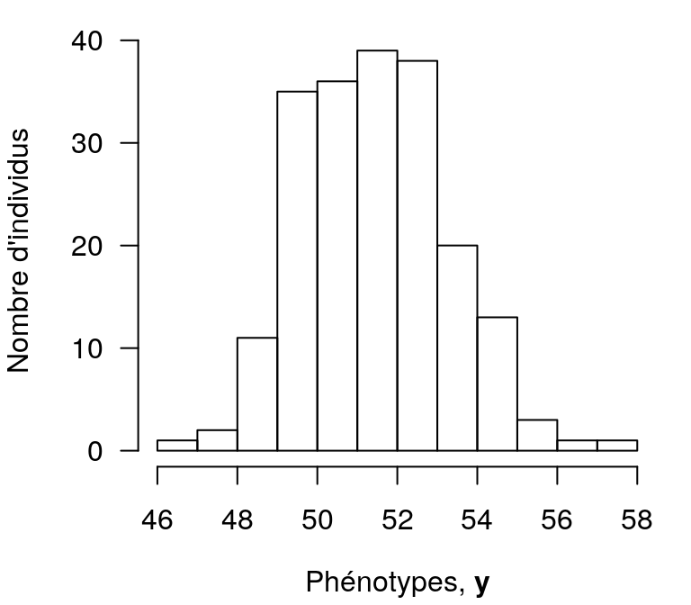

```r
par(mar = c(4, 4, 1, 1))
hist(phenotypes, las = 1, main = "",
     xlab = expression(paste("Phénotypes, ", bold(y))),
     ylab = "Nombre d'individus")
```

- Relation génotypes - phénotypes

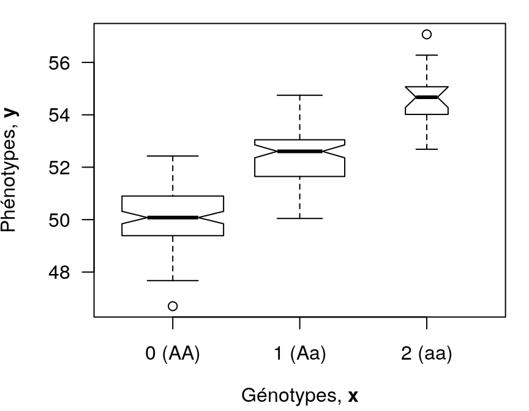

```r
par(mar = c(4, 4, 1, 1))
boxplot(phenotypes ~ genotypes,
        xlab = expression(paste("Génotypes, ", bold(x))),
        ylab = expression(paste("Phénotypes, ", bold(y))),
        varwidth = TRUE, notch = TRUE, las = 1, xaxt = "n", at = 0:2)
axis(side = 1, at = 0:2, labels = c("0 (AA)", "1 (Aa)", "2 (aa)"))
```

## Implémentation (facile)

- Sous R, la fonction `lm` implémente l’estimation par maximum de vraisemblance

```r
fit <- lm(y ~ x, data=dat)
```

- Vérification des hypothèses du modèle (homoscédasticité, normalité, indépendance)

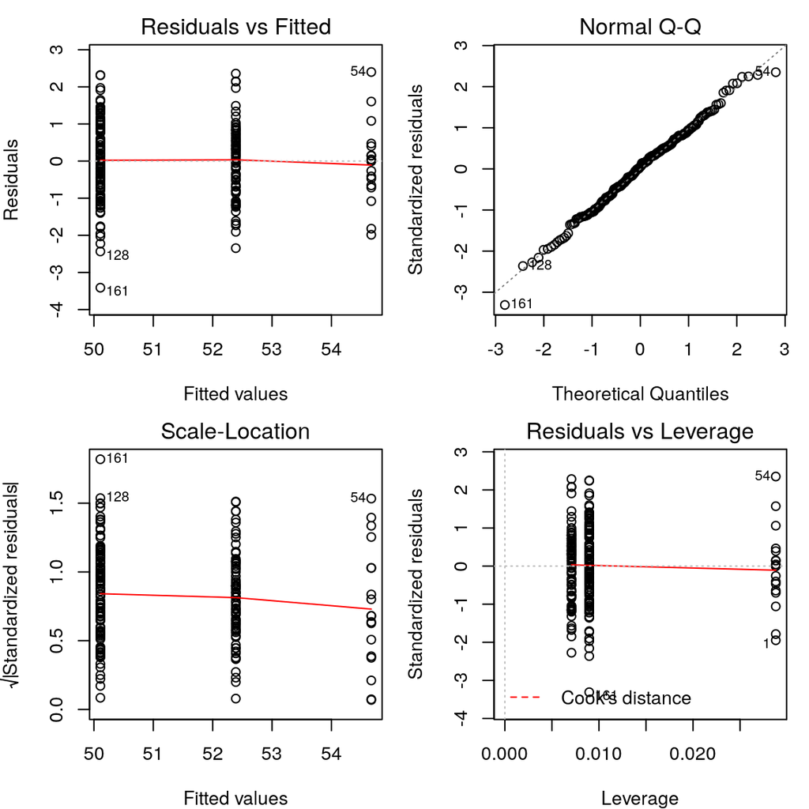

```r
par(mfrow=c(2, 2), mar = c(4, 4, 2, 1))
plot(fit)
```

```r
summary(fit)
```

```
##
## Call:
## lm(formula = y ~ x, data = dat)
##
## Residuals:
##    Min     1Q Median     3Q    Max
## -3.411 -0.701  0.055  0.688  2.399
##
## Coefficients:
##             Estimate Std. Error t value Pr(>|t|)
## (Intercept)  50.1085     0.0981   511.0   <2e-16 ***
## x             2.2814     0.1125    20.3   <2e-16 ***
## ---
## Signif. codes:  0 '***' 0.001 '**' 0.01 '*' 0.05 '.' 0.1 ' ' 1
##
## Residual standard error: 1.04 on 198 degrees of freedom
## Multiple R-squared:  0.675,  Adjusted R-squared:  0.673
## F-statistic:  411 on 1 and 198 DF,  p-value: <2e-16
```

- Représentation graphique du modèle

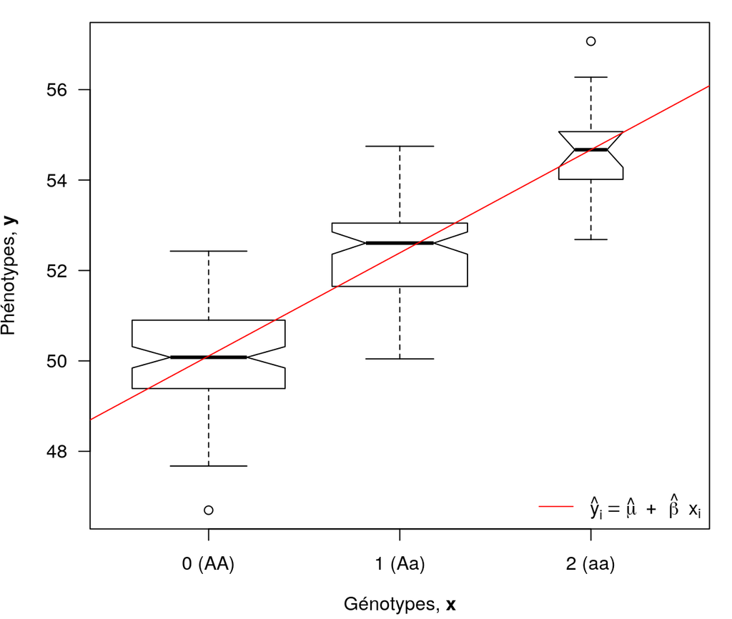

```r
par(mar = c(4, 4, 1, 1))
boxplot(phenotypes ~ genotypes,
        xlab=expression(paste("Génotypes, ", bold(x))),
        ylab=expression(paste("Phénotypes, ", bold(y))),
        varwidth=TRUE, notch=TRUE, las=1, xaxt="n", at=0:2)
axis(side=1, at=0:2, labels=c("0 (AA)", "1 (Aa)", "2 (aa)"))
abline(a=coefficients(fit)[1], b=coefficients(fit)[2], col="red")
legend("bottomright",
       legend=expression(hat(y)[i]==hat(mu)~+~hat(beta)~x[i]),
       col="red", lty=1, bty="n")
```

## Implémentation (plus difficile)

- Il faut d’abord écrire une fonction calculant l’opposé de la log-vraisemblance

```r
negLogLik <- function(mu, beta, sigma){
  - sum(dnorm(x=dat$y, mean=mu + beta * dat$x, sd=sigma, log=TRUE))
}
```

- Puis demander à la fonction `mle` de la maximiser (en spécifiant que le paramètre \(\sigma\) ne peut pas être négatif ou nul)

```r
fit2 <- mle(negLogLik, start=list(mu=mean(dat$y), beta=0, sigma=1),
            method="L-BFGS-B", nobs=nrow(dat),
            lower=c(-Inf,-Inf,10^(-6)),
            upper=c(+Inf,+Inf,+Inf))
```

```r
summary(fit2)
```

```
## Maximum likelihood estimation
##
## Call:
## mle(minuslogl = negLogLik, start = list(mu = mean(dat$y), beta = 0,
##     sigma = 1), method = "L-BFGS-B", nobs = nrow(dat), lower = c(-Inf,
##     -Inf, 10^(-6)), upper = c(+Inf, +Inf, +Inf))
##
## Coefficients:
##       Estimate Std. Error
## mu       50.11     0.0976
## beta      2.28     0.1119
## sigma     1.03     0.0515
##
## -2 log L: 579
```

## Evaluer les résultats

## Sélection de modèles

- Evaluation de l’ajustement du modèle aux données
- Dans notre cas de régression linéaire simple, on peut utiliser le coefficient de détermination \(R^2\)

```r
summary(fit)$r.squared
```

```
## [1] 0.675
```

- On peut facilement vérifier que cette valeur renvoyée par la fonction `lm` correspond à la formule :

\[ \begin{align} R^2 = \frac{\hat{\beta}^2 \; Var(\boldsymbol{x})}{\hat{\beta}^2 \; Var(\boldsymbol{x}) + \hat{\sigma}^2} \end{align}` \]

```r
(coefficients(fit)[2]^2 * var(dat$x)) /
  (coefficients(fit)[2]^2 * var(dat$x) + summary(fit)$sigma^2)
```

```
##     x
## 0.674
```

## Estimation des paramètres

- Prenons l’exemple de \(\beta\), comme nous avons simulé les données, nous connaissons sa vraie valeur

```r
beta
```

```
## [1] 2.45
```

- Après avoir ajusté le modèle avec la fonction `lm`, nous pouvons récupérer l’estimation de ce paramètre (\(\hat{\beta}\))

```r
(beta.hat <- coefficients(fit)[2])
```

```
##    x
## 2.28
```

- Pour comparer les deux, on définit une fonction de perte (*loss function*) reliant le paramètre (\(\beta\)) à son estimation (\(\hat{\beta}\))
- On utilise une fonction quadratique, dont on prend l’espérance, ce qui donne l’erreur quadratique moyenne (*mean squared error*)

\[ \begin{align} MSE = E \left( (\hat{\beta} - \beta)^2 \right) \end{align} \]

- On calcule sa racine carrée pour que le résultat soit dans la même unité que le paramètre

```r
(rmse.beta <- sqrt((beta.hat - beta)^2))
```

```
##     x
## 0.172
```

## Prédiction de données

- On peut aussi calculer l’erreur quadratique moyenne avec les phénotypes déjà observés (on parle de *in-sample predictions*)

```r
y <- phenotypes
y.hat <- (coefficients(fit)[1] + coefficients(fit)[2] * genotypes)
errors <- y - y.hat
(rmse.y <- sqrt(mean(errors^2)))
```

```
## [1] 1.03
```

- On peut aussi utiliser la fonction `predict`

```r
errors <- phenotypes - predict(fit)
(rmse.y <- sqrt(mean(errors^2)))
```

```
## [1] 1.03
```

- Le vecteur *errors* correspond aux résidus du modèle

```r
head(errors)
```

```
##       1       2       3       4       5       6
## -1.9859  0.0643  1.2021 -0.9601 -0.6865  0.5462
```

```r
head(resid(fit))
```

```
##       1       2       3       4       5       6
## -1.9859  0.0643  1.2021 -0.9601 -0.6865  0.5462
```

```r
(rmse.y <- sqrt(mean(resid(fit)^2)))
```

```
## [1] 1.03
```

- De façon plus intéressante, on souhaiterai évaluer les prédictions phénotypiques sur \(n_{\text{new}}\) nouveaux individus
- Pour cela, on commence par simuler de nouvelles données, \(\mathcal{D}_{\text{new}} = \{(y_{i,\text{new}} \, | \, x_{i,\text{new}})\}\), toujours avec les *mêmes* “vraies” valeurs des paramètres, \(\Theta = \{\mu, \beta, \sigma\}\)

```r
set.seed(1944) # année de découverte de l'ADN comme support des gènes
n.new <- 100
x.new <- sample(x=c(0,1,2), size=n.new, replace=TRUE, prob=calcGenoFreq(f))
y.new <- mu + beta * x.new + rnorm(n=n.new, mean=0, sd=sigma)
```

- Puis on utilise les estimations des paramètres obtenues précédemment pour prédire les nouveaux phénotypes à partir des nouveaux génotypes, \(\tilde{\mathcal{D}}_{\text{new}} = \{(\tilde{y}_{i,\text{new}} = \hat{\mu} + \hat{\beta} \, x_{i,\text{new}})\}\) (*out-of-sample predictions*)

```r
y.new.tilde <- (coefficients(fit)[1] + coefficients(fit)[2] * x.new)
```

- Enfin, on calcule l’erreur quadratique moyenne de prédiction

```r
errors.tilde <- y.new - y.new.tilde
(rmspe <- sqrt(mean(errors.tilde^2)))
```

```
## [1] 0.8
```

Graphiquement :

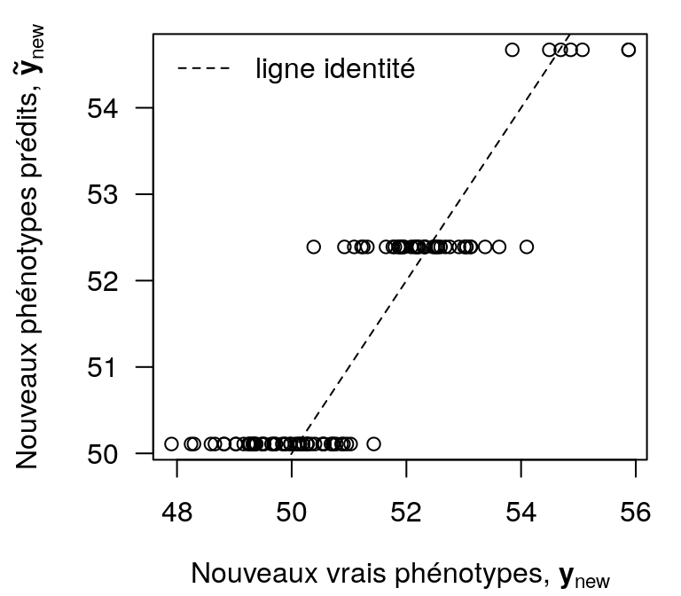

```r
par(mar = c(4, 4.5, 1, 1))
plot(x=y.new, y=y.new.tilde, las=1,
     xlab=expression(paste("Nouveaux vrais phénotypes, ", bold(y)[new])),
     ylab=expression(paste("Nouveaux phénotypes prédits, ", bold(tilde(y))[new])))
abline(a=0, b=1, lty=2)
legend("topleft", legend="ligne identité", lty=2, bty="n")
```

## Perspectives

## Explorer les simulations possibles

- La simulation est un outil particulièrement utile pour explorer comment un modèle répond à des changements dans les données et les paramètres
- On pourrait par exemple avoir envie de savoir ce qui se passe si la taille de l’échantillon (\(n\)) varie
- Idem, que se passe-t-il si, à \(n\) et \(\sigma\) fixés, on modifie \(\beta\) ?

## Ré-écrire le modèle

- Modèle sous forme *multivariée* \[ \begin{align} \boldsymbol{y} \, | \, \boldsymbol{x}, \mu, \beta, \sigma \; \sim \mathcal{N}_n(\boldsymbol{1} \mu + \boldsymbol{x} \beta, \sigma^2 I_n) \end{align} \]
- avec :
  - \(\boldsymbol{y}\) : vecteur de dimension \(n\) contenant les phénotypes,
  - \(\boldsymbol{x}\) : vecteur de dimension \(n\) contenant les génotypes,
  - \(\boldsymbol{1}\) : vecteur de dimension \(n\) ne contenant que des \(1\),
  - \(I_n\) : matrice identité de dimension \(n \times n\)
- Exemple d’un vecteur aléatoire de longueur 2, \(\boldsymbol{\theta}\), distribué selon une loi Normale bivariée \(\mathcal{N}_2(\boldsymbol{\mu}, \Sigma)\) : \[ \boldsymbol{\theta} \sim \mathcal{N}_2(\boldsymbol{\mu}, \Sigma) \Leftrightarrow \begin{align} \begin{bmatrix} \theta_1 \\ \theta_2 \end{bmatrix} \sim \mathcal{N}_2 \left( \begin{bmatrix} \mu_1 \\ \mu_2 \end{bmatrix}, \begin{bmatrix} \sigma_1^2 & \sigma_{12}^2 \\ \sigma_{12}^2 & \sigma_2^2 \end{bmatrix} \right) \end{align} \]
- On fixe quelques valeurs

```r
mu.1 <- 5
mu.2 <- 23
mu <- c(mu.1, mu.2)
var.1 <- 1
var.2 <- 2
rho <- 0.8
covar.12 <- rho * sqrt(var.1 * var.2)
Sigma <- matrix(c(var.1, covar.12, covar.12, var.2), nrow=2, ncol=2)
```

- On simule des vecteurs aléatoires avec la fonction `mvrnorm` du package [MASS](https://cran.r-project.org/web/packages/MASS/index.html)

```r
theta <- mvrnorm(n=100, mu=mu, Sigma=Sigma)
dim(theta)
```

```
## [1] 100   2
```

```r
head(theta)
```

```
##      [,1] [,2]
## [1,] 4.00 22.7
## [2,] 6.25 23.0
## [3,] 5.35 23.8
## [4,] 5.67 22.4
## [5,] 6.57 24.1
## [6,] 4.48 23.3
```

- Représentation graphique

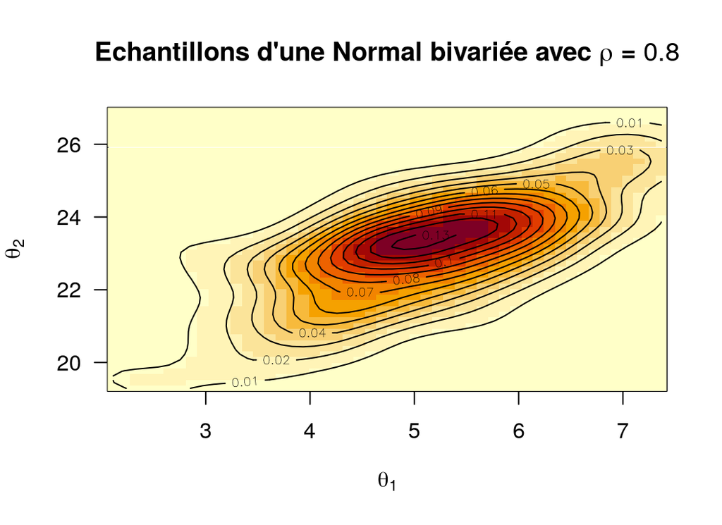

```r
bivn.kde <- kde2d(x=theta[,1], y=theta[,2], n=50)
image(bivn.kde, xlab=expression(theta[1]), ylab=expression(theta[2]), las=1,
      main=bquote(bold(paste("Echantillons d'une Normal bivariée avec ",
                             rho, " = ", .(rho)))))
contour(bivn.kde, add=T)
```